# Ciberseguridad en estudiantes de licenciatura

Vistas

Equipo 1: Diego Arellano, Emilio Ramírez, Fernanda Monter, Fernando Lango

02/12/2021

Las vistas creadas en este [Script](https://github.com/FerLango/Proyecto-db/blob/main/Vistas/Vistas.sql) para responder nuestras preguntas de interés son las siguientes:

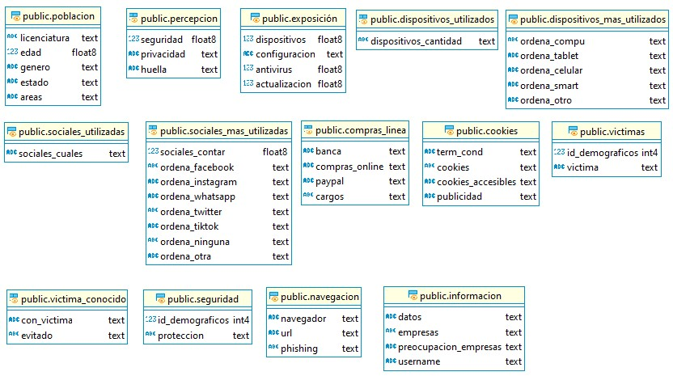

# 1 Población

- ¿Cómo se compone nuestra población?

En esta vista incluimos las variables licenciatura, edad, género, estado y áreas de la carrera que corresponden a las preguntas del cuestionario:

- ¿Eres alumno de licenciatura?
- ¿Qué edad tienes?
- Género
- ¿En qué estado se encuentra ubicada tu Universidad?
- ¿A qué área corresponde tu carrera?

# 2 Percepción

- ¿Qué percepción tienen sobre la ciberseguridad?

En esta vista incluimos las variables seguridad, privacidad y huella que corresponden a las preguntas del cuestionario:

- ¿Del 1 al 5 que tanto te preocupa tu seguridad digital?
- ¿Sabes en qué consiste la privacidad digital?
- ¿Conoces el término de huella digital?

# 3 Exposición

- ¿Qué tan expuestos se encuentran?

En esta vista incluimos las variables dispositivos, configuración, antivirus y actualización que corresponden a las preguntas del cuestionario:

- ¿Cuántos dispositivos con acceso internet tienes?
- ¿Permites que todas tus aplicaciones accedan a tu cámara, micrófono, ubicación, fotos y rastreo?
- ¿Cuántos de estos dispositivos cuentan con antivirus?
- ¿Cuántos tienen su última actualización?

# 4 Dispositivos utilizados

- ¿Cuáles son sus dispositivos utilizados?

En esta vista incluimos la variable dispositivos_cantidad que corresponde a las preguntas del cuestionario:

- ¿Cuáles de estos dispositivos tienes?

# 5 Dispositivos más utilizados

- ¿Cuáles son los dispositivos más utilizados?

En esta vista incluimos las variables ordena_compu, ordena_tablet, ordena_celular, ordena_smart, ordena_otro que corresponden a las preguntas del cuestionario:

- Ordena de mayor a menor los tres dispositivos que más usas

# 6 Redes sociales utilizadas

- ¿Cuáles son las redes sociales utilizadas?

En esta vista incluimos la variable sociales_cuales que corresponden a las preguntas del cuestionario:

- ¿Cuáles redes sociales tienes?

# 7 Redes sociales más utilizadas

- ¿Cuáles son las redes sociales más utilizadas?

En esta vista incluimos las variables sociales_contar, ordena_facebook, ordena_instagram, ordena_whatsapp, ordena_twitter, ordena_tiktok, ordena_ninguna y ordena_otra que corresponden a las preguntas del cuestionario:

- Ordena de mayor a menor las tres redes sociales que más utilizas

# 8 Compras en línea

- ¿Cuáles son sus hábitos en compras en línea?

En esta vista incluimos las variables banca, compras_online, paypal y cargos que corresponden a las preguntas del cuestionario:

- ¿Tienes banca electrónica?
- ¿Has realizado compras en línea?
- Al realizar compras en línea, ¿utilizas una tarjeta digital o alguna plataforma de sistema de pagos en línea (PayPal)?
- ¿Te han llegado cargos que no autorizaste de alguna aplicación con la que estabas en un periodo prueba (ej. Spotify, Netflix, etc.)?

# 9 Cookies

- ¿Qué importancia le dan a los términos y condiciones y cookies al navegar?

En esta vista incluimos las variables term_cond, cookies, cookies_accesibles y publicidad que corresponden a las preguntas del cuestionario:

- Cuando te registras en algún sitio web, ¿te detienes a leer sus términos y condiciones, o los aceptas sin leerlos?
- Cuando entras a un sitio web, ¿configuras las cookies, o aceptas el default?
- ¿Crees que sería conveniente para el usuario que los términos y condiciones o cookies fueran presentados de una forma más accesible para todo tipo de público?
- Después de buscar algún artículo en internet, ¿la publicidad que se le muestra en redes sociales corresponde a ese artículo?

# 10 Víctimas

- ¿Han sido víctimas de amenazas y ataques digitales?

En esta vista incluimos las variables id_demograficos y victima que corresponden a las preguntas del cuestionario:

- ¿Has sido víctima de alguno de estos escenarios?

# 11 Víctimas conocidas

- ¿Conocen a alguien que haya sido víctima de un ataque digital?
- ¿Crees que estos ataque se pudieron haber evitado?

En esta vista incluimos las variables con_victima y evitado que corresponden a las preguntas del cuestionario:

- ¿Conoces a alguien que haya sido víctima de estos escenarios?
- ¿Crees que lo pudiste haber evitado de alguna manera?

# 12 Seguridad

- ¿Cuáles son las medidas de seguridad más utilizadas?

En esta vista incluimos las variables id_demográficos y protección que corresponden a las preguntas del cuestionario:

- Con el fin de proteger tus cuentas de redes sociales, ¿cuáles de las siguientes opciones realizas?

# 13 Navegación

- ¿Qué medidas de protección tiene activadas en el navegador?

En esta vista incluimos las variables navegador, url y phishing que corresponden a las preguntas del cuestionario:

- ¿Tienes configurado en tu navegador alguna protección de privacidad?
- ¿Verificas si todos los URL de los sitios que visitas inician con https?
- ¿Tienes activada alguna protección contra phishing (engaño para obtener tus datos a través de internet) y malware (programa malicioso que daña tu dispositivo)?

# 14 Información

- ¿Qué tanto les preocupa su información?
- ¿Qué tan fácil dan su información?

En esta vista incluimos las variables datos, empresas, preocupación sobre empresas y username que corresponden a las preguntas del cuestionario:

- ¿Sientes que los datos que proporcionas en la web son de importancia/utilidad para los sitios en los que navegas?
- ¿Crees que las empresas utilizan la información de manera adecuada?
- ¿Te preocupa que tu información sea utilizada con fines distintos a los que autorizaste?